# Titanic Machine Learning from Disaster

### Analyzing Titanic Survival Data with Python: A Step-by-Step Machine Learning Tutorial

### 1. Define the Problem

The sinking of the RMS Titanic is one of the most famous shipwreck in history. On April 15,1912, during its maiden voyage, Titanic sank after colliding with an iceberg, killing 1502 of the 225 passengers and crew. This sensasional tragedy shocked the international community and resulted in improved safety regulations for ships.

Salah satu alasan mengapa kapal karam menyebabkan korban jiwa adalah karena tidak tersedianya sekoci/perahu penolong yang cukup untuk penumpang dan awak kapal. Meskipun ada unsur keberuntungan selamat dari tenggelamnya kapal tersebut, beberapa kelompok orang lebih mungkin untuk selamat dibandingkan dengan kelompok lainnya, seperti wanita, anak-anak dan kelas atas.

#### What particularly we need do in this challenge ?

In this challenge, we will use machine learning tools to analyze and predict which passengers are most likely to survive the tragedy.

### 2. Gather the Data

**(1) train.csv**  
Contains details of a group of passengers on the ship (specifically **891 passengers**).  
The values in the column (**"Survived"**) can be used to determine whether each passenger survived or not:  
code 1: passenger survived.  
code 0: passenger died.

**(2) test.csv**  
Contains similar information but does not reveal the **ground truth** for each passenger. Our task here is to predict the survival outcomes for another **418 passengers** included in it.

| Variable | Definition | Key |
| --- | --- | --- |
| PassengerId | A uniqe identifier for each passenger |  |
| Survival | Indicates if a passenger survived the Titanic disaster | 0 = No, 1 = Yes |
| Pclass | The ticket class, which serves as a proxy for socio-economic status | 1 = 1st, 2 = 2nd, 3 = 3rd |
| Name | The name of the passenger |  |
| Sex | The gender of the passenger | male or female |
| Age | The age of the passenger in years |  |
| Sibsp | # of siblings / spouses aboard the Titanic |  |
| Parch | # of parents / children aboard the Titanic |  |
| Ticket | Ticket number |  |
| Fare | Passenger fare |  |
| Cabin | Cabin number |  |
| Embarked | Port of Embarkation | C = Cherbourg, Q = Queenstown, S = Southampton |

### 3. Preprocessing Data

#### 3.1 Import Libraries

```python
#load packages
import pandas as pd
import matplotlib
import numpy as np
import scipy as sp

#  Display Dataframe
import IPython
from IPython.display import display

#misc libraries
import random
import time

#ignore warnings
import warnings
warnings.filterwarnings('ignore')
```

#### 3.2. Importing Libraries for Data Modeling

We will use the **scikit-learn** library, which is quite popular for developing machine learning algorithm for data visualization, we will use the **matplotlib** and **seaborn** libraries

```python
# Common Model Algorithms
from sklearn import svm, tree, linear_model, neighbors, naive_bayes, ensemble, discriminant_analysis, gaussian_process
from xgboost import XGBClassifier


# Common Model Helpers
from sklearn.preprocessing import OneHotEncoder, LabelEncoder
from sklearn import model_selection
from sklearn import metrics

# Visualization
import matplotlib as mpl
import matplotlib.pyplot as plt
import matplotlib.pylab as pylab
import seaborn as sns

# Classifier Modules
from sklearn.linear_model import LogisticRegression
from sklearn.svm import SVC, LinearSVC
from sklearn.neighbors import KNeighborsClassifier
from sklearn.tree import DecisionTreeClassifier
from sklearn.ensemble import RandomForestClassifier
from sklearn.naive_bayes import GaussianNB
from sklearn.linear_model import Perceptron
from sklearn.linear_model import SGDClassifier

#Configure Visualization Defaults
#%matplotlib inline = show plots in Jupyter Notebook browser
%matplotlib inline
mpl.style.use('ggplot')
sns.set_style('white')
pylab.rcParams['figure.figsize'] = 12,8
```

#### 3.3. Importing the Dataset

This dataset can be acquired from Kaggle's **Titanic: Machine Learning from Disaster competition** (https://www.kaggle.com/c/titanic/data ).

```python
train = pd.read_csv("data_titanic/train.csv")
test = pd.read_csv("data_titanic/test.csv")

# concat these two datasets, this will come handy while processing the data
# dataset =  pd.concat(objs=[train, test], axis=0).reset_index(drop=True)
```

#### 3.4 Analyze by Describing Data

**1) What feature are available in the dataset?**

```python
# Displaying Train Data Information
display(train.tail())
print(train.info())
```

|  | PassengerId | Survived | Pclass | Name | Sex | Age | SibSp | Parch | Ticket | Fare | Cabin | Embarked |
| --- | --- | --- | --- | --- | --- | --- | --- | --- | --- | --- | --- | --- |
| 886 | 887 | 0 | 2 | Montvila, Rev. Juozas | male | 27.0 | 0 | 0 | 211536 | 13.00 | NaN | S |
| 887 | 888 | 1 | 1 | Graham, Miss. Margaret Edith | female | 19.0 | 0 | 0 | 112053 | 30.00 | B42 | S |
| 888 | 889 | 0 | 3 | Johnston, Miss. Catherine Helen "Carrie" | female | NaN | 1 | 2 | W./C. 6607 | 23.45 | NaN | S |
| 889 | 890 | 1 | 1 | Behr, Mr. Karl Howell | male | 26.0 | 0 | 0 | 111369 | 30.00 | C148 | C |
| 890 | 891 | 0 | 3 | Dooley, Mr. Patrick | male | 32.0 | 0 | 0 | 370376 | 7.75 | NaN | Q |

```
<class 'pandas.core.frame.DataFrame'>
RangeIndex: 891 entries, 0 to 890
Data columns (total 12 columns):
 #   Column       Non-Null Count  Dtype
---  ------       --------------  -----
 0   PassengerId  891 non-null    int64
 1   Survived     891 non-null    int64
 2   Pclass       891 non-null    int64
 3   Name         891 non-null    object
 4   Sex          891 non-null    object
 5   Age          714 non-null    float64
 6   SibSp        891 non-null    int64
 7   Parch        891 non-null    int64
 8   Ticket       891 non-null    object
 9   Fare         891 non-null    float64
 10  Cabin        204 non-null    object
 11  Embarked     889 non-null    object
dtypes: float64(2), int64(5), object(5)
memory usage: 83.7+ KB
None
```

Based on the information in the table above, it can be seen that:

- There are **891 samples** with **12 features**
- **Numerical Features**: Age, Fare, SibSp, dan Parch
- **Categorical Features**: Sex, Embarked, Survived, and Pclass.
- **Alphanumeric Features**: Ticket and Cabin (Contains both alphabets and the numeric value)
- **Text Features**: Name.

**2) Which features may contain missing values, errors, or typos?**

**Looking into the train dataset**

```python
print(train.isnull().sum())
print("-"*40)
```

```
PassengerId      0
Survived         0
Pclass           0
Name             0
Sex              0
Age            177
SibSp            0
Parch            0
Ticket           0
Fare             0
Cabin          687
Embarked         2
dtype: int64
----------------------------------------
```

**Note:**

- We can see that **Age** feature has **177 rows** of missing data.
- The **Cabin** feature has **687 rows** of missing data.
- The **Embark** feature has **2 rows** of missing data.

**Looking into the testing dataset**

```python
print(test.isnull().sum())
print("-"*40)
```

```
PassengerId      0
Pclass           0
Name             0
Sex              0
Age             86
SibSp            0
Parch            0
Ticket           0
Fare             1
Cabin          327
Embarked         0
dtype: int64
----------------------------------------
```

**Note:**

- There are **86 rows** missing in the **Age** feature.
- There are **327 rows** with no **Cabin** information.
- **1 rows** is missing **Fare** information

#### 3.5. Cleaning the Data.

Now we will proceed with data cleaning to achieve better model accuracy.

#### Why missing values treatment is required?

Data hilang pada sekumpulan data training dapat mengurangi keakuratan/kesesuaian suatu model sehingga dapat menyebabkan hasil prediksi atau klasifikasi menjadi kurang akurat.

Missing data in a training dataset can reduce the accuracy or fit of a model, potentially leading to less accuracate predictions or classifications.

```python
#complete missing age with median
train['Age'].fillna(train['Age'].median(), inplace = True)

#complete embarked with mode
train['Embarked'].fillna(train['Embarked'].mode()[0], inplace = True)

#delete the cabin feature and others previously stated to exclude in train dataset.
drop_column = ['PassengerId', 'Name', 'Cabin', 'Ticket']
train.drop(drop_column, axis = 1, inplace = True)
```

```python
train.isnull().sum()
```

```
Survived    0
Pclass      0
Sex         0
Age         0
SibSp       0
Parch       0
Fare        0
Embarked    0
dtype: int64
```

```python
#complete missing age with median
test['Age'].fillna(test['Age'].median(), inplace = True)

#complete missing age with median
test['Fare'].fillna(train['Fare'].median(), inplace = True)

#delete the cabin feature and others previously stated to exclude in train dataset.
drop_column = ['PassengerId', 'Name', 'Cabin', 'Ticket']
test.drop(drop_column, axis = 1, inplace = True)
```

```python
test.isnull().sum()
```

```
Pclass      0
Sex         0
Age         0
SibSp       0
Parch       0
Fare        0
Embarked    0
dtype: int64
```

### 4. Exploratory Data Analysis

#### 4.1 Analyze Feature Survived:

Let's start with Survived column. It contains integer 1 or 0 which correspond to surviving (1 = Survived, 0 = Not Survived)

```
How many people and what proportion of individuals survived for each class?
```

|  | Survived | Survival Rate |
| --- | --- | --- |
| 0 | 549 | 0.62 |
| 1 | 342 | 0.38 |

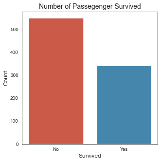

```python
survival = train['Survived'].value_counts().to_frame()
survival['Survival Rate'] = (survival['Survived']/len(train)).round(2)

# Displaying DataFrame
print('How many people and what proportion of individuals survived for each class?')
display(survival)

#########################################################
# Visualize with a countplot
plt.subplots(figsize = (5,5))
sns.countplot(x='Survived', data = train.replace({'Survived': {0: 'No', 1: 'Yes'}}))
plt.title('Number of Passegenger Survived', fontsize = 14)
plt.ylabel('Count')
plt.show()
```

**Observation:**  
As expected, most passenger in the train data did not survive. Only **38%** (342 passanger) survived the disaster.

#### 4.2 Analyze Feature Pclass vs Survived:

The **Pclass** column contains the socio-economic status of passengers and can be categorized into three levels.  
1 = Upper, 2 = Middle, 3 = Lower

```
How many people and what proportion of individuals survived for each class?
```

|  | Pclass | Not Survived | Survived | People | Survival Rate |
| --- | --- | --- | --- | --- | --- |
| 0 | 1 | 80 | 136 | 216 | 0.63 |
| 1 | 2 | 97 | 87 | 184 | 0.47 |
| 2 | 3 | 372 | 119 | 491 | 0.24 |

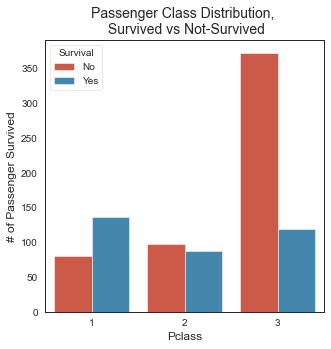

```python
pclass_group = train.groupby(['Pclass','Survived']).size().unstack().reset_index()

# Changing column Names from 0 and 1 'Not Survived' and 'Survived'
pclass_group = pclass_group.rename(columns={0:"Not Survived", 1:'Survived'})

# Removing the Top-Level Column Name ('Survived)
pclass_group = pclass_group.rename_axis(columns=None)

# Calculating 'Total Count' & 'Survival Rate'
pclass_group['People'] = pclass_group['Not Survived'] + pclass_group['Survived']
pclass_group['Survival Rate'] = (pclass_group['Survived'] / pclass_group['People']).round(2)

# Filtering the DataFrame for 'Pclass', 'People', and 'Survival Rate' columns
# pclass_group = pclass_group[['Pclass', 'People', 'Survival Rate']]

# Displaying the DataFrame
print('How many people and what proportion of individuals survived for each class?')
display(pclass_group)

#########################################################
# Visualize with a countplot
plt.subplots(figsize = (5,5))
plot = sns.countplot(x='Pclass', hue='Survived', data=train)

# Fixing title & legend
plt.title('Passenger Class Distribution, \n Survived vs Not-Survived', fontsize = 14)
plt.ylabel('# of Passenger Survived')
legend = plot.get_legend()
legend.set_title('Survival')
legend.texts[0].set_text('No')
legend.texts[1].set_text('Yes')
plt.show()
```

Based on the results, it's clear that Passenger Class (Pclass) is an important factor to consider. Here's a simpler breakdown:

- A large number of passengers, specifically 491, were in third class. However, the survival rate for this group was low, with only 24% surviving.
- In contrast, first-class passengers had a significantly higher survival chance, with nearly 63% surviving the disaster.
- Second-class passengers had a moderate survival rate, with about 48% managing to survive.

#### 4.3.1 Analyze Feature Sex vs Survived:

in 1912, women were generally considered a weaker group in need of protection. This perspective invites exploration into whether people at that time upheld the duty of protection even when faced with the possibility of death

```
How many people and what proportion of individuals survived for each class?
```

|  | Sex | Not Survived | Survived | People | Survival Rate |
| --- | --- | --- | --- | --- | --- |
| 0 | female | 81 | 233 | 314 | 0.74 |
| 1 | male | 468 | 109 | 577 | 0.19 |

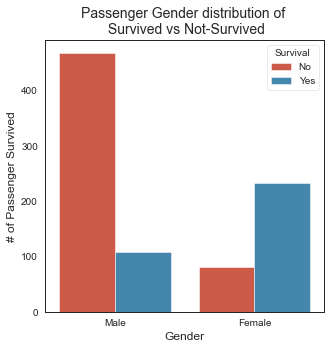

```python
sex_group = train.groupby(['Sex','Survived']).size().unstack().reset_index()
# Changing column Names from 0 and 1 'Not Survived' and 'Survived'
sex_group = sex_group.rename(columns={0:"Not Survived", 1:'Survived'})

# Removing the Top-Level Column Name ('Survived)
sex_group = sex_group.rename_axis(columns=None)

# Calculating 'Total Count' & 'Survival Rate'
sex_group['People'] = sex_group['Not Survived'] + sex_group['Survived']
sex_group['Survival Rate'] = (sex_group['Survived'] / sex_group['People']).round(2)

# Filtering the DataFrame for 'Pclass', 'People', and 'Survival Rate' columns
# pclass_group = pclass_group[['Pclass', 'People', 'Survival Rate']]

# Displaying the DataFrame
print('How many people and what proportion of individuals survived for each class?')
display(sex_group)

#########################################################
# Visualize with a countplot
plt.subplots(figsize = (5,5))
plot = sns.countplot(x="Sex", hue="Survived", data=train)

# Fixing title & label
plt.title('Passenger Gender distribution of \n Survived vs Not-Survived', fontsize = 14)
plt.xlabel('Gender')
plt.ylabel('# of Passenger Survived')
plt.xticks([0,1], ['Male', 'Female'])

# Fixing legend
legend = plot.get_legend()
legend.set_title('Survival')
legend.texts[0].set_text('No')
legend.texts[1].set_text('Yes')
plt.show()
```

Even though most passengers were men (577), women made up the majority of those who survived. This points out that women's chance of surviving (74%) was four times greater than men's (19%). This big difference shows that during emergencies, the rule of saving "women and children first" was indeed followed.

#### 4.3.2 Analyze Feature Pclass & Sex vs Survived:

- What is the impact of ticket class (Pclass) and gender (Sex) on the likelihood of passengers surviving?
- Can these factors provide insights into who had a greater chance of survival?

Here’s a simplified way to approach the analysis:

|  | Pclass | Sex | Not Survived | Survived | Survival Rate |
| --- | --- | --- | --- | --- | --- |
| 0 | 1 | female | 3 | 91 | 0.97 |
| 1 | 1 | male | 77 | 45 | 0.37 |
| 2 | 2 | female | 6 | 70 | 0.92 |
| 3 | 2 | male | 91 | 17 | 0.16 |
| 4 | 3 | female | 72 | 72 | 0.50 |
| 5 | 3 | male | 300 | 47 | 0.14 |

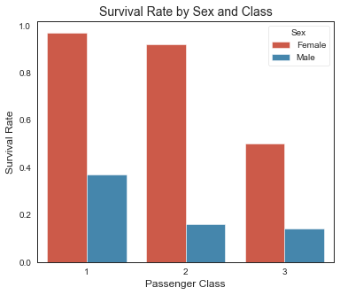

```python
# Melakukan groupby, unstack dan reset index (memudahkan plotting) pada data train
grouped = train.groupby(['Pclass', 'Sex','Survived']).size().unstack().reset_index()
# Mengubah nama kolom dari 0 dan 1 menjadi 'Not Survived' dan 'Survived'
grouped = grouped.rename(columns={0:"Not Survived", 1:'Survived'})

# Menghitung 'Survival Rate'
grouped['Survival Rate'] = (grouped['Survived'] / (grouped['Survived'] + grouped['Not Survived'])).round(2)

# Menghilangkan nama level kolom atas ('Survived')
grouped = grouped.rename_axis(columns=None)
display(grouped)    # menampilkan dataframe

##################################################################################
# Visualize with a countplot
plt.subplots(figsize = (6,5))
plot = sns.barplot(x='Pclass', y='Survival Rate', hue='Sex', data=grouped)

# Fixing title & label
plt.title('Survival Rate by Sex and Class', fontsize = 14)
plt.xlabel('Passenger Class')
plt.ylabel('Survival Rate')
plt.xticks([0,1,2], ['1', '2', '3'])

# Fixing legend
legend = plot.get_legend()
legend.set_title('Sex')
legend.texts[0].set_text('Female')
legend.texts[1].set_text('Male')
plt.show()
```

- Here, it's evident that aside from the ticket class impact, the most crucial factor for survival is gender.
- It can be concluded that both women and men who purchased first-class tickets had a significantly higher chance of survival compared to other classes.
- The survival rates for each gender & ticket class are as follows:  
  Class 1 Survival Rate: Female: 97%, Male: 36%.  
  Class 2 Survival Rate: Female: 92%, Male: 15%.  
  Class 3 Survival Rate: Female: 50%, Male: 13%.

#### 4.4.1 Analyze Feature Age vs Survived:

- Does the age of passengers affect their chances of survival?

To analyze the correlation between age groups and survival rates, we can follow these steps:

```python
train['AgeBin'] = pd.cut(train['Age'].astype(int), 5)  # dibagi mennjadi 5 kelompok
train[['AgeBin','Survived']].groupby(['AgeBin'], as_index=False).mean().sort_values(by='AgeBin', ascending=True)
```

|  | AgeBin | Survived |
| --- | --- | --- |
| 0 | (-0.08, 16.0] | 0.550000 |
| 1 | (16.0, 32.0] | 0.344762 |
| 2 | (32.0, 48.0] | 0.403226 |
| 3 | (48.0, 64.0] | 0.434783 |
| 4 | (64.0, 80.0] | 0.090909 |

Replace the **Age** values with ordinal numbers based on the following bins:

```python
#buat kolom Age Categori
train['AgeBin'] = train['Age'].astype(int)
#Mengganti nilai Age2 dengan nilai ordinal

train.loc[(train['AgeBin']<=16), 'AgeBin'] = 0
train.loc[(train['AgeBin']>16) & (train['AgeBin']<=32), 'AgeBin'] = 1
train.loc[(train['AgeBin']>32) & (train['AgeBin']<=48), 'AgeBin'] = 2
train.loc[(train['AgeBin']>48) & (train['AgeBin']<=64), 'AgeBin'] = 3
train.loc[(train['AgeBin']>64), 'AgeBin'] = 4
train.head()
```

|  | Survived | Pclass | Sex | Age | SibSp | Parch | Fare | Embarked | AgeBin |
| --- | --- | --- | --- | --- | --- | --- | --- | --- | --- |
| 0 | 0 | 3 | male | 22.0 | 1 | 0 | 7.2500 | S | 1 |
| 1 | 1 | 1 | female | 38.0 | 1 | 0 | 71.2833 | C | 2 |
| 2 | 1 | 3 | female | 26.0 | 0 | 0 | 7.9250 | S | 1 |
| 3 | 1 | 1 | female | 35.0 | 1 | 0 | 53.1000 | S | 2 |
| 4 | 0 | 3 | male | 35.0 | 0 | 0 | 8.0500 | S | 2 |

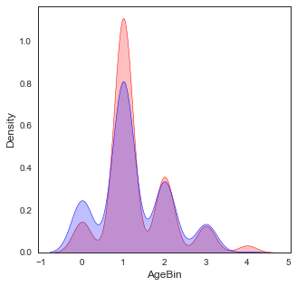

```python
fig,axs=plt.subplots(figsize=(5,5))
sns.set_style(style='darkgrid')
sns.kdeplot(train.loc[train['Survived']==0, 'AgeBin'], color='r', shade=True, label='Not Survived')
sns.kdeplot(train.loc[train['Survived']==1, 'AgeBin'], color='b', shade=True, label='Survived')
plt.show()
```

- The density plot shows that only the youngest passengers (<16 years) had a noticeable priority in rescue efforts.
- A large number of passengers between 16-32 years failed to survive.

For further analysis, one idea might be to explore involving the gender or Pclass features together using swarm plots, since age alone appears to have limited impact on survival probabilities.

#### 4.4.2 Analyze Feature Age & Sex vs Survived:

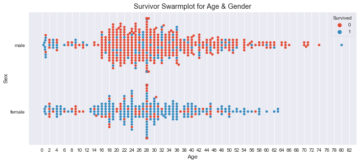

```python
plt.subplots(figsize=(12,5))
plt.xticks(list(range(0,100,2)))
sns.swarmplot(data=train, x='Age', y='Sex', hue='Survived').set_title('Survivor Swarmplot for Age & Gender')
plt.show()
```

#### 4.4.3 Analyze Feature Age & Pclass vs Survived:

Furthermore, we can also observe the influence of Pclass and Age together in predicting survival probability.

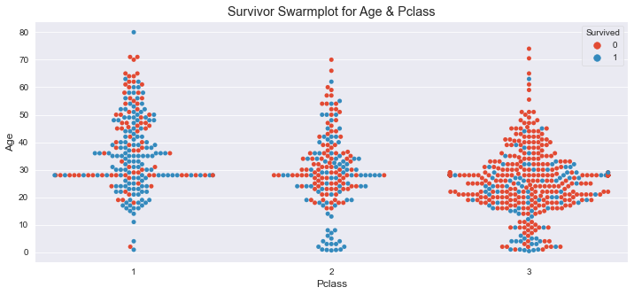

```python
plt.subplots(figsize=(12,5))
plt.xticks(list(range(0,100,2)))
sns.swarmplot(data=train, x='Pclass', y='Age', hue='Survived').set_title('Survivor Swarmplot for Age & Pclass')
plt.show()
```

Looking at the swarm plot results above, we can observe that Class 1 passengers do not have many children. Perhaps rich people generally have fewer children?

#### 4.5.1 Analyze Feature Embarked vs Survived:

- Can the place of departure affect the chances of survival?

Reasoning and intuition may not lead us to believe that the place of departure is also important to analyze, but we cannot assume it is.  
One approach to analyzing this is to use a calculation plot of 3 locations at Embarkation: Southampton, Cherbourg, and Quenstown:

|  | Embarked | People | Survived |
| --- | --- | --- | --- |
| 0 | S | 646 | 0.339009 |
| 1 | C | 168 | 0.553571 |
| 2 | Q | 77 | 0.389610 |

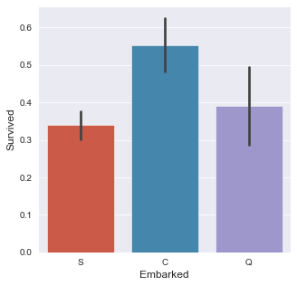

```python
embarked_group = train[['Embarked','Survived']].groupby(['Embarked'], as_index=False).mean()
# Calculate the total number of people for each 'Embarked' category and convert it to a DataFrame
people = train['Embarked'].value_counts().reset_index()
people.columns = ['Embarked', 'People']

# Merge 'embarked_group' with 'people' based on 'Embarked'
embarked_group = pd.merge(people, embarked_group , on='Embarked')
display(embarked_group)

# Making a plot
plt.subplots(figsize= (5,5))
sns.barplot(x='Embarked', y='Survived', data=train)
plt.show()
```

Observation:

- There are three observations in the Embarked feature: Southampton(S), Cherbourg(C), Queenstown(C).
- Most passengers embarked from Southampton (646 people). However, only 33% survived the sinking of the Titanic.
- The highest survival rate was for the group of passengers who departed from Cherhbourg at 55%.

Although it is important to look at the data without making any previous assumptions. But a question arises:

- Why did many passengers from Southampton not survive while there were many passengers on the ship?
- Why was the probability of survival at Cherbourg higher than that of passengers departing from Southampton and Quenstown?

To answer these conjectures may require additional features such as **Pclass** or **Sex** to provide insight.

#### 4.5.1 Analyze Feature Embarked & Pclass vs Survived:

Based on the previous information, we know that passenger class has a big influence on survival rates. One factor that could be decisive is the number of 1st Class passengers boarding from Cherbourg. Therefore, the next analysis involves the influence of **Pclass** to see the survival rate of passengers.

| Embarked | Pclass | Survived |
| --- | --- | --- |
| C | 1 | 59 |
|  | 2 | 9 |
|  | 3 | 25 |
| Q | 1 | 1 |
|  | 2 | 2 |
|  | 3 | 27 |
| S | 1 | 76 |
|  | 2 | 76 |
|  | 3 | 67 |

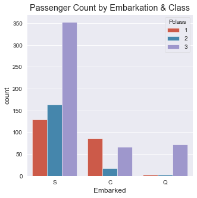

```python
embarked_pclass = train.groupby(['Embarked','Pclass']).Survived.sum().to_frame()
display(embarked_pclass)

# Visualize
plt.subplots(figsize=(5,5))
sns.countplot(x='Embarked' , hue = 'Pclass', data=train).set_title('Passenger Count by Embarkation & Class')
plt.show()
```

Based on the analysis above, it can be seen that:

- Passengers departing from Southampton were mostly in class 3, where class 3 passengers are likely to have limited access to safety facilities and are often less prioritized in the evacuation process than higher class passengers.
- Passengers departing from Cherbourg were mostly in class 1, where class 1 passengers are likely to have better access to safety facilities and are prioritized during emergency evacuations.

### 5. Feature Engineering

We have learned a lot from the exploratory data analysis. Now we can start feature engineering. In this section, we will select suitable features for melative data classifiers and convert categorical features into numerical form.

```python
from sklearn.preprocessing import LabelEncoder
column = ['Sex', 'Embarked']

label = LabelEncoder()
for encoder in column:
    train[encoder] = label.fit_transform(train[encoder])
    test[encoder]  = label.fit_transform(test[encoder])
```

```python
#delete the cabin feature and others previously stated to exclude in train dataset.
train['Age'] = train['AgeBin']
train.drop('AgeBin', axis = 1, inplace = True)
```

```python
# Define data training and testing
X_train = train.drop('Survived', axis=1)
Y_train = train['Survived']
X_test = test

X_train.shape, Y_train.shape, X_test.shape
```

```
((891, 7), (891,), (418, 7))
```

```python
X_train.head()
```

|  | Pclass | Sex | Age | SibSp | Parch | Fare | Embarked |
| --- | --- | --- | --- | --- | --- | --- | --- |
| 0 | 3 | 1 | 1 | 1 | 0 | 7.2500 | 2 |
| 1 | 1 | 0 | 2 | 1 | 0 | 71.2833 | 0 |
| 2 | 3 | 0 | 1 | 0 | 0 | 7.9250 | 2 |
| 3 | 1 | 0 | 2 | 1 | 0 | 53.1000 | 2 |
| 4 | 3 | 1 | 2 | 0 | 0 | 8.0500 | 2 |

### 6. Modeling the Data

Now we are ready to train the model and predict the required solution. There are many predictive modeling algorithms to choose from but understanding the type of problem and solution requirements is necessary to narrow down the scope of models to evaluate.

- Ensemble Methods
- Gaussian Processes
- GLM
- Navies Bayes
- Nearest Neighbor
- Support Vector Machine (SVM)
- Decision Trees
- Discriminant Analysis
- XGBoost

```python
from sklearn import ensemble, gaussian_process, linear_model, naive_bayes, neighbors, svm, tree, discriminant_analysis
from sklearn.metrics import accuracy_score
from sklearn.model_selection import train_test_split, cross_val_score
from xgboost import XGBClassifier
import numpy as np
import pandas as pd

# Classify function to evaluate the model
def classify(model, X, y):
    x_train, x_test, y_train, y_test = train_test_split(X, y, test_size=0.25, random_state=42)
    model.fit(x_train, y_train)
    acc = accuracy_score(y_test, model.predict(x_test))
    cv_score = np.mean(cross_val_score(model, X, y, cv=5))
    return acc, cv_score

# List of Machine Learning Algorithms to evaluate
MLA = [
    # Ensemble Methods
    ensemble.AdaBoostClassifier(),
    ensemble.BaggingClassifier(),
    ensemble.ExtraTreesClassifier(),
    ensemble.GradientBoostingClassifier(),
    ensemble.RandomForestClassifier(),

    # Gaussian Processes
    gaussian_process.GaussianProcessClassifier(),

    # GLM
    linear_model.LogisticRegression(),
    linear_model.PassiveAggressiveClassifier(),
    linear_model.RidgeClassifierCV(),
    linear_model.SGDClassifier(),

    # Navies Bayes
    naive_bayes.BernoulliNB(),
    naive_bayes.GaussianNB(),

    # Nearest Neighbor
    neighbors.KNeighborsClassifier(),

    # SVM
    svm.SVC(probability=True),
    svm.NuSVC(probability=True),
    svm.LinearSVC(),

    # Trees
    tree.DecisionTreeClassifier(),
    tree.ExtraTreeClassifier(),

    # Discriminant Analysis
    discriminant_analysis.LinearDiscriminantAnalysis(),
    discriminant_analysis.QuadraticDiscriminantAnalysis(),

    # xgboost
    XGBClassifier()
]

# Evaluate each model and record results
results = []
for model in MLA:
    name = model.__class__.__name__
    acc, cv_score = classify(model, X_train, Y_train)
    results.append((name, acc, cv_score))

# Convert the result into a DataFrame for better display
results_df = pd.DataFrame(results, columns=['Model', 'Accuracy', 'CV Score'])

# Displaying the DataFrame sorted by CV Score
display(results_df.sort_values(by='CV Score', ascending=False))
```

[output not shown]

|  | Model | Accuracy | CV Score |
| --- | --- | --- | --- |
| 3 | GradientBoostingClassifier | 0.820628 | 0.822692 |
| 20 | XGBClassifier | 0.802691 | 0.812629 |
| 1 | BaggingClassifier | 0.789238 | 0.812592 |
| 4 | RandomForestClassifier | 0.789238 | 0.803609 |
| 2 | ExtraTreesClassifier | 0.789238 | 0.799121 |
| 17 | ExtraTreeClassifier | 0.784753 | 0.791275 |
| 11 | GaussianNB | 0.789238 | 0.791262 |
| 6 | LogisticRegression | 0.802691 | 0.791243 |
| 0 | AdaBoostClassifier | 0.784753 | 0.789059 |
| 19 | QuadraticDiscriminantAnalysis | 0.811659 | 0.787879 |
| 16 | DecisionTreeClassifier | 0.780269 | 0.786787 |
| 10 | BernoulliNB | 0.784753 | 0.783385 |
| 8 | RidgeClassifierCV | 0.766816 | 0.783378 |
| 18 | LinearDiscriminantAnalysis | 0.766816 | 0.781131 |
| 15 | LinearSVC | 0.775785 | 0.778871 |
| 14 | NuSVC | 0.771300 | 0.776662 |
| 5 | GaussianProcessClassifier | 0.793722 | 0.760994 |
| 12 | KNeighborsClassifier | 0.780269 | 0.753117 |
| 9 | SGDClassifier | 0.771300 | 0.675651 |
| 13 | SVC | 0.659193 | 0.669010 |
| 7 | PassiveAggressiveClassifier | 0.748879 | 0.636313 |

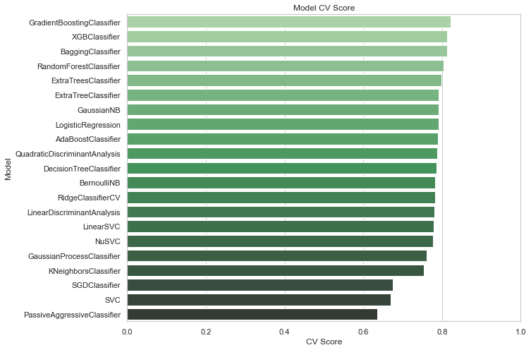

```python
import matplotlib.pyplot as plt
import seaborn as sns

# Setting the plot style
sns.set(style="whitegrid")

# Plot for CV Score
plt.figure(figsize=(10, 8))
ax2 = sns.barplot(x="CV Score", y="Model", data=results_df.sort_values(by="CV Score", ascending=False), palette="Greens_d")
ax2.set(xlim=(0, 1))
plt.title('Model CV Score')
plt.xlabel('CV Score')
plt.ylabel('Model')

plt.show()
```

From the above barplot, we can clearly see that the accuracy of the Gradient Boosting Classifier is the best of all other classifiers. Next let us apply this method on the test data.

### 6. Prediction

```python
# Step 1: Identify the best model
best_model_name = results_df.sort_values(by='CV Score', ascending=False).iloc[0]['Model']
best_model = [model for model in MLA if model.__class__.__name__ == best_model_name][0]

# Step 2: Retrain the best model on the entire dataset
best_model.fit(X_train, Y_train)

# Step 3: Perform prediction (assuming X_test is the new data to be predicted)
prediction = best_model.predict(X_test)

# Tampilkan prediksi
print(f"Prediction using model {best_model_name}:\n{prediction}")
```

```
Prediction using model GradientBoostingClassifier:
[0 1 0 0 0 0 0 0 1 0 0 0 1 0 1 1 0 0 0 1 0 0 1 0 1 0 1 0 0 0 0 1 0 0 0 0 0
 0 0 0 0 0 0 1 1 0 0 0 1 1 0 0 1 1 0 0 0 0 0 1 0 0 0 1 0 1 1 0 0 1 1 0 0 0
 1 0 0 1 0 1 0 0 0 0 0 0 1 0 1 0 1 0 1 0 0 0 1 0 0 0 1 0 0 0 0 0 0 0 0 0 0
 1 1 1 1 0 0 1 0 1 1 0 1 0 0 1 0 1 0 0 0 0 0 0 0 0 0 0 0 0 0 1 0 0 0 0 0 0
 0 0 1 0 0 0 1 0 1 0 0 0 1 0 1 0 0 0 0 0 1 0 0 0 0 0 1 1 1 0 1 1 0 0 1 0 1
 0 1 0 0 0 0 0 0 0 0 0 0 0 0 1 1 1 0 1 0 0 1 0 1 0 0 0 0 1 1 0 1 0 1 0 1 0
 1 0 1 0 0 1 0 0 0 1 0 0 0 0 0 0 1 1 1 1 0 0 0 0 1 0 1 0 1 0 0 0 0 0 0 0 1
 0 0 0 1 0 0 0 0 0 0 0 0 0 1 1 0 1 0 0 0 0 0 0 1 0 0 0 0 0 0 0 0 0 0 0 0 0
 1 0 0 0 0 0 0 0 1 1 0 0 0 0 0 0 0 1 1 1 0 0 0 1 0 0 0 0 1 0 1 0 0 0 1 0 0
 0 0 0 0 0 0 0 0 0 0 1 0 1 0 1 0 1 1 0 0 0 1 0 1 0 0 0 0 1 1 0 1 0 0 0 1 0
 0 1 0 0 1 1 0 0 0 1 0 0 0 0 0 1 0 0 0 0 0 1 0 0 0 1 0 1 0 0 1 0 1 0 0 0 0
 0 1 0 1 1 0 0 1 0 0 0]
```

```python
# Store passenger Id
ids = pd.read_csv("data_titanic/test.csv")[["PassengerId"]].values

# Membuat DataFrame dari hasil prediksi
submission = pd.DataFrame({
    'PassengerId': ids.ravel(),
    'Survived': prediction
})

display(submission)
```

|  | PassengerId | Survived |
| --- | --- | --- |
| 0 | 892 | 0 |
| 1 | 893 | 1 |
| 2 | 894 | 0 |
| 3 | 895 | 0 |
| 4 | 896 | 0 |
| ... | ... | ... |
| 413 | 1305 | 0 |
| 414 | 1306 | 1 |
| 415 | 1307 | 0 |
| 416 | 1308 | 0 |
| 417 | 1309 | 0 |

418 rows × 2 columns